# Problem 1 and Problem 2

Problem 1: What are the factors that influence the number of cases? Problem 2: What are the factors that influence the resolution rate?

Part 1: Data Cleaning and EDA

1-1 Data Cleaning

```r
data_311 <- read.csv("311_Cases_cleaned.csv")
head(data_311)
```

```
  X neighborhood year mobile.dumm                         case     month
1 1      Bayview 2012           1 Street and Sidewalk Cleaning September
2 2      Bayview 2012           0 Street and Sidewalk Cleaning  December
3 3      Bayview 2012           1 Street and Sidewalk Cleaning    August
4 4      Bayview 2012           0 Street and Sidewalk Cleaning   October
5 5      Bayview 2012           0            Abandoned Vehicle     March
6 6      Bayview 2012           0                 Streetlights  December
                                request
1                      General Cleaning
2                           Bulky Items
3                      General Cleaning
4                      General Cleaning
5               Abandoned Vehicle - SUV
6 Streetlight - Light_Flickering_On_Off
                                       notes photo.dumm income population
```

[output cut: 34 more lines]

```r
print(nrow(data_311))
```

```
[1] 519919
```

```r
print(ncol(data_311))
```

```
[1] 27
```

```r
library(dplyr)
data_311_group_rate <- data_311 %>%
  group_by(neighborhood, year, registered, turnout, turnout_one_lag, turnout_two_lag, income, population, white, black, asian, num_cases) %>%
  summarise(resolution_rate = mean(resolution_rate), .groups = 'drop')
head(data_311_group_rate)
```

```
# A tibble: 6 × 13
  neighborhood    year registered turnout turnout_one_lag turnout_two_lag income
  <chr>          <int>      <int>   <dbl>           <dbl>           <dbl>  <dbl>
1 Bayview         2012      19566    61.2            47.2            69.7 56718
2 Bayview         2014      16907    43.0            61.2            47.2 57885.
3 Bayview         2016      20174    64.6            43.0            61.2 53866
4 Bayview         2018      19914    56.6            64.6            43.0 56502.
5 Bernal Heights  2012      18917    78.8            67.1            85   90041
6 Bernal Heights  2014      16852    61.5            78.8            67.1 94577.
# ℹ 6 more variables: population <int>, white <dbl>, black <dbl>, asian <dbl>,
#   num_cases <int>, resolution_rate <dbl>
```

```r
print(nrow(data_311_group_rate))
```

```
[1] 80
```

```r
print(ncol(data_311_group_rate))
```

```
[1] 13
```

```r
print(data_311_group_rate)
```

```
# A tibble: 80 × 13
   neighborhood   year registered turnout turnout_one_lag turnout_two_lag income
   <chr>         <int>      <int>   <dbl>           <dbl>           <dbl>  <dbl>
 1 Bayview        2012      19566    61.2            47.2            69.7 5.67e4
 2 Bayview        2014      16907    43.0            61.2            47.2 5.79e4
 3 Bayview        2016      20174    64.6            43.0            61.2 5.39e4
 4 Bayview        2018      19914    56.6            64.6            43.0 5.65e4
 5 Bernal Heigh…  2012      18917    78.8            67.1            85   9.00e4
 6 Bernal Heigh…  2014      16852    61.5            78.8            67.1 9.46e4
 7 Bernal Heigh…  2016      18660    85.5            61.5            78.8 1.10e5
 8 Bernal Heigh…  2018      18214    80.5            85.5            61.5 1.33e5
 9 Chinatown      2012      17612    68.5            56.4            80.1 2.03e4
10 Chinatown      2014      14539    50.6            68.5            56.4 2.13e4
# ℹ 70 more rows
# ℹ 6 more variables: population <int>, white <dbl>, black <dbl>, asian <dbl>,
#   num_cases <int>, resolution_rate <dbl>
```

```r
numeric_data_311 <- data_311_group_rate[ , !names(data_311_group_rate)%in%c("neighborhood", "year")]
head(numeric_data_311)
```

```
# A tibble: 6 × 11
  registered turnout turnout_one_lag turnout_two_lag income population white
       <int>   <dbl>           <dbl>           <dbl>  <dbl>      <int> <dbl>
1      19566    61.2            47.2            69.7 56718       23467 0.200
2      16907    43.0            61.2            47.2 57885.      25163 0.148
3      20174    64.6            43.0            61.2 53866       24815 0.123
4      19914    56.6            64.6            43.0 56502.      24863 0.113
5      18917    78.8            67.1            85   90041       25779 0.628
6      16852    61.5            78.8            67.1 94577.      25840 0.585
# ℹ 4 more variables: black <dbl>, asian <dbl>, num_cases <int>,
#   resolution_rate <dbl>
```

1-2 correlation matrix

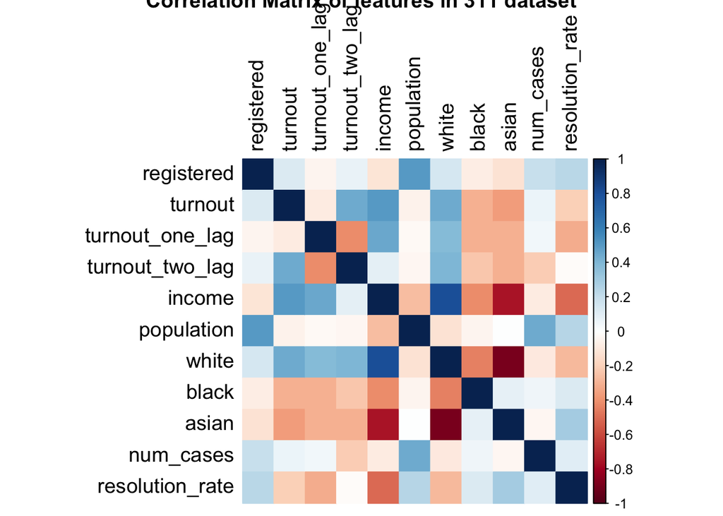

Fig-1: Correlation matrix of some numerical features of different neighborhood in San Francisco

```r
correlation_matrix_311 <- cor(numeric_data_311)
#install.packages("corrplot")
library(corrplot)
corrplot(correlation_matrix_311, method = "color",
         tl.col = "black", tl.cex = 1.2,
         title = "Correlation Matrix of features in 311 dataset")
```

1-3 scatter plots

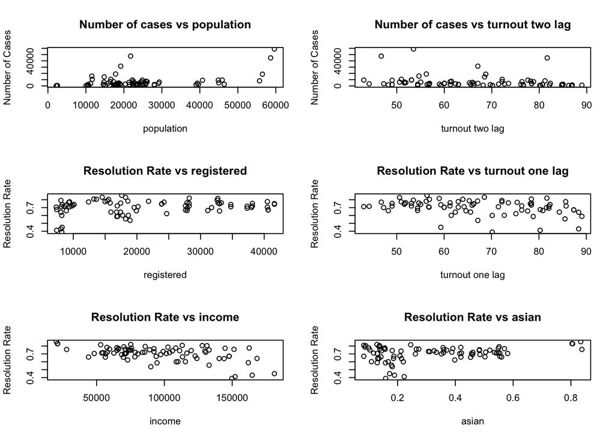

```r
library(ggplot2)
par(mfrow = c(3,2))
plot(numeric_data_311$population, numeric_data_311$num_cases, main = "Number of cases vs population", xlab = "population", ylab = "Number of Cases")
plot(numeric_data_311$turnout_two_lag, numeric_data_311$num_cases, main = "Number of cases vs turnout two lag", xlab = "turnout two lag", ylab = "Number of Cases")
plot(numeric_data_311$registered, numeric_data_311$resolution_rate, main = "Resolution Rate vs registered", xlab = "registered", ylab = "Resolution Rate")
plot(numeric_data_311$turnout_one_lag, numeric_data_311$resolution_rate, main = "Resolution Rate vs turnout one lag", xlab = "turnout one lag", ylab = "Resolution Rate")
plot(numeric_data_311$income, numeric_data_311$resolution_rate, main = "Resolution Rate vs income", xlab = "income", ylab = "Resolution Rate")
plot(numeric_data_311$asian, numeric_data_311$resolution_rate, main = "Resolution Rate vs asian", xlab = "asian", ylab = "Resolution Rate")
```

Part 2 Problem 1 – model selection

```r
library(ISLR)
library(leaps)
library(tidyverse)
library(caret)
```

2-1 Best subset selection

```r
regfit_311=regsubsets(num_cases~.,numeric_data_311)
summary(regfit_311)
```

```
Subset selection object
Call: regsubsets.formula(num_cases ~ ., numeric_data_311)
10 Variables  (and intercept)
                Forced in Forced out
registered          FALSE      FALSE
turnout             FALSE      FALSE
turnout_one_lag     FALSE      FALSE
turnout_two_lag     FALSE      FALSE
income              FALSE      FALSE
population          FALSE      FALSE
white               FALSE      FALSE
black               FALSE      FALSE
asian               FALSE      FALSE
resolution_rate     FALSE      FALSE
1 subsets of each size up to 8
Selection Algorithm: exhaustive
         registered turnout turnout_one_lag turnout_two_lag income population
1  ( 1 ) " "        " "     " "             " "             " "    "*"
2  ( 1 ) " "        " "     " "             "*"             " "    "*"
3  ( 1 ) " "        "*"     " "             "*"             " "    "*"
4  ( 1 ) " "        "*"     " "             "*"             " "    "*"
5  ( 1 ) " "        "*"     " "             "*"             "*"    "*"
6  ( 1 ) " "        "*"     " "             "*"             "*"    " "
7  ( 1 ) " "        "*"     " "             "*"             "*"    "*"
8  ( 1 ) "*"        "*"     " "             "*"             "*"    "*"
         white black asian resolution_rate
1  ( 1 ) " "   " "   " "   " "
2  ( 1 ) " "   " "   " "   " "
3  ( 1 ) " "   " "   " "   " "
4  ( 1 ) " "   "*"   " "   " "
5  ( 1 ) " "   " "   "*"   " "
6  ( 1 ) "*"   "*"   "*"   " "
7  ( 1 ) "*"   "*"   "*"   " "
8  ( 1 ) "*"   "*"   "*"   " "
```

```r
reg.summary_8=summary(regfit_311)
```

```r
regfit_311_full=regsubsets(num_cases~.,numeric_data_311, nvmax=10)
summary(regfit_311_full)
```

```
Subset selection object
Call: regsubsets.formula(num_cases ~ ., numeric_data_311, nvmax = 10)
10 Variables  (and intercept)
                Forced in Forced out
registered          FALSE      FALSE
turnout             FALSE      FALSE
turnout_one_lag     FALSE      FALSE
turnout_two_lag     FALSE      FALSE
income              FALSE      FALSE
population          FALSE      FALSE
white               FALSE      FALSE
black               FALSE      FALSE
asian               FALSE      FALSE
resolution_rate     FALSE      FALSE
1 subsets of each size up to 10
Selection Algorithm: exhaustive
          registered turnout turnout_one_lag turnout_two_lag income population
1  ( 1 )  " "        " "     " "             " "             " "    "*"
2  ( 1 )  " "        " "     " "             "*"             " "    "*"
3  ( 1 )  " "        "*"     " "             "*"             " "    "*"
4  ( 1 )  " "        "*"     " "             "*"             " "    "*"
5  ( 1 )  " "        "*"     " "             "*"             "*"    "*"
6  ( 1 )  " "        "*"     " "             "*"             "*"    " "
7  ( 1 )  " "        "*"     " "             "*"             "*"    "*"
8  ( 1 )  "*"        "*"     " "             "*"             "*"    "*"
9  ( 1 )  "*"        "*"     " "             "*"             "*"    "*"
10  ( 1 ) "*"        "*"     "*"             "*"             "*"    "*"
          white black asian resolution_rate
1  ( 1 )  " "   " "   " "   " "
2  ( 1 )  " "   " "   " "   " "
3  ( 1 )  " "   " "   " "   " "
4  ( 1 )  " "   "*"   " "   " "
5  ( 1 )  " "   " "   "*"   " "
6  ( 1 )  "*"   "*"   "*"   " "
7  ( 1 )  "*"   "*"   "*"   " "
8  ( 1 )  "*"   "*"   "*"   " "
9  ( 1 )  "*"   "*"   "*"   "*"
10  ( 1 ) "*"   "*"   "*"   "*"
```

```r
reg.summary_10=summary(regfit_311_full)
```

```r
coef(regfit_311_full,10)
```

```
    (Intercept)      registered         turnout turnout_one_lag turnout_two_lag
   6.561391e+04   -3.225633e-02    3.023217e+02    1.069123e+01   -3.428518e+02
         income      population           white           black           asian
  -1.624981e-01    1.427502e-01   -4.118835e+04   -7.056287e+04   -6.772759e+04
resolution_rate
   1.985604e+03
```

```r
print(reg.summary_10$rsq)# The last model with all variables performs the best
```

```
 [1] 0.1958946 0.2355447 0.2737148 0.2792588 0.3074725 0.3437284 0.3551574
 [8] 0.3559073 0.3560640 0.3561258
```

```r
print(reg.summary_10$adjr2)# The 7th variable without registered, turnout_one_lag, and resolution_rate performs the best
```

```
 [1] 0.1855856 0.2156887 0.2450457 0.2408192 0.2606801 0.2897883 0.2924643
 [8] 0.2833335 0.2732723 0.2628107
```

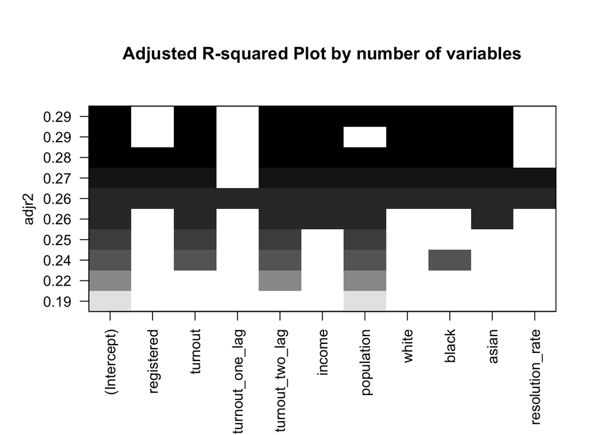

```r
plot(regfit_311_full,scale="adjr2", main = "Adjusted R-squared Plot by number of variables")
```

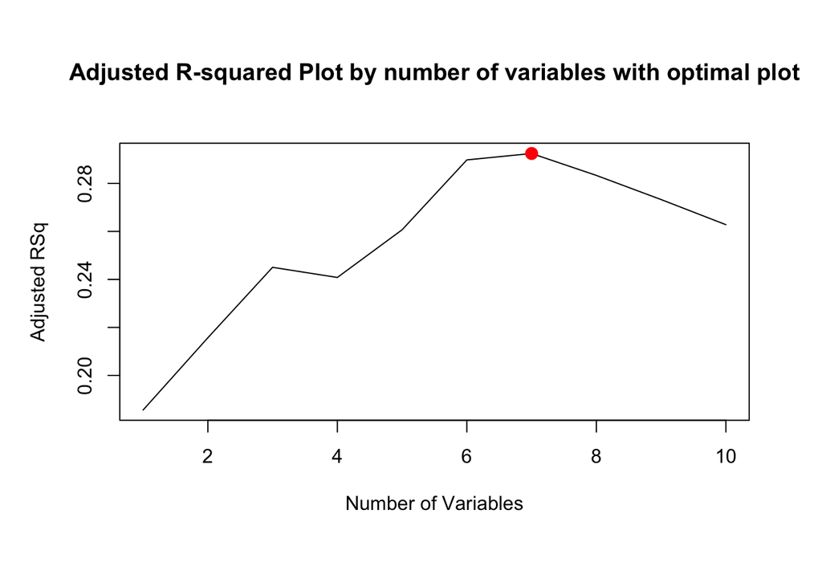

```r
plot(reg.summary_10$adjr2,xlab="Number of Variables",ylab="Adjusted RSq",type="l", main = "Adjusted R-squared Plot by number of variables with optimal plot")
m=which.max(reg.summary_10$adjr2);
points(m,reg.summary_10$adjr2[m], col="red",cex=2,pch=20)
```

```r
plot(reg.summary_10$cp,xlab="Number of Variables",ylab="Cp",type='l', main = "Cp Plot by number of variables")
m=which.min(reg.summary_10$cp)
print(c("optimal feature subset-size according to cp:",m))# population should also be removed
```

```
[1] "optimal feature subset-size according to cp:"
[2] "6"
```

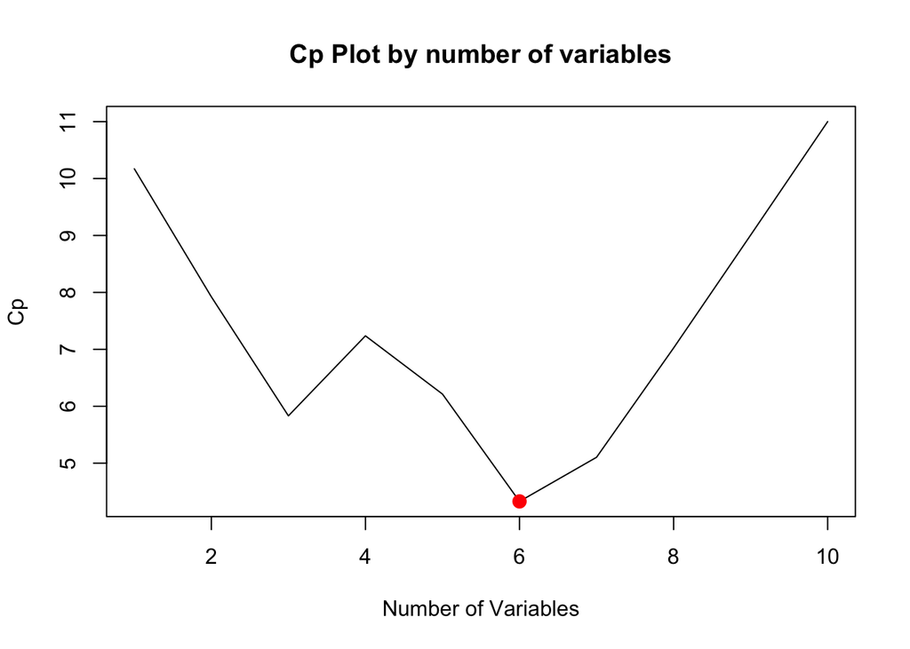

```r
points(m,reg.summary_10$cp[m],col="red",cex=2,pch=20)
```

```r
m=which.min(reg.summary_10$bic)
print(c("optimal feature subset-size according to BIC:",m))
```

```
[1] "optimal feature subset-size according to BIC:"
[2] "1"
```

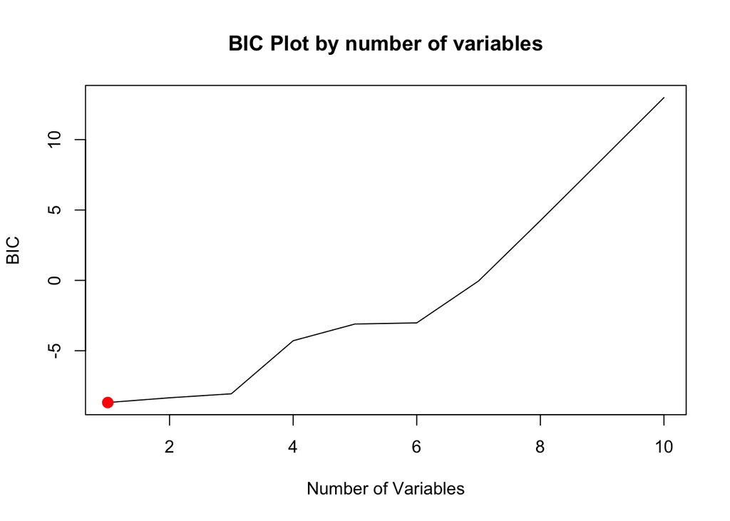

```r
plot(reg.summary_10$bic,xlab="Number of Variables",ylab="BIC",type='l', main = "BIC Plot by number of variables")
points(m,reg.summary_10$bic[m],col="red",cex=2,pch=20) # Only population should be used
```

2-2 Forward and Backward stepwise selection

```r
regfit.fwd=regsubsets(num_cases~.,numeric_data_311, nvmax=10,method="forward")
summary(regfit.fwd)
```

```
Subset selection object
Call: regsubsets.formula(num_cases ~ ., numeric_data_311, nvmax = 10,
    method = "forward")
10 Variables  (and intercept)
                Forced in Forced out
registered          FALSE      FALSE
turnout             FALSE      FALSE
turnout_one_lag     FALSE      FALSE
turnout_two_lag     FALSE      FALSE
income              FALSE      FALSE
population          FALSE      FALSE
white               FALSE      FALSE
black               FALSE      FALSE
asian               FALSE      FALSE
resolution_rate     FALSE      FALSE
1 subsets of each size up to 10
Selection Algorithm: forward
          registered turnout turnout_one_lag turnout_two_lag income population
1  ( 1 )  " "        " "     " "             " "             " "    "*"
2  ( 1 )  " "        " "     " "             "*"             " "    "*"
3  ( 1 )  " "        "*"     " "             "*"             " "    "*"
4  ( 1 )  " "        "*"     " "             "*"             " "    "*"
5  ( 1 )  " "        "*"     " "             "*"             " "    "*"
6  ( 1 )  " "        "*"     " "             "*"             "*"    "*"
7  ( 1 )  " "        "*"     " "             "*"             "*"    "*"
8  ( 1 )  "*"        "*"     " "             "*"             "*"    "*"
9  ( 1 )  "*"        "*"     " "             "*"             "*"    "*"
10  ( 1 ) "*"        "*"     "*"             "*"             "*"    "*"
          white black asian resolution_rate
1  ( 1 )  " "   " "   " "   " "
2  ( 1 )  " "   " "   " "   " "
3  ( 1 )  " "   " "   " "   " "
4  ( 1 )  " "   "*"   " "   " "
5  ( 1 )  " "   "*"   "*"   " "
6  ( 1 )  " "   "*"   "*"   " "
7  ( 1 )  "*"   "*"   "*"   " "
8  ( 1 )  "*"   "*"   "*"   " "
9  ( 1 )  "*"   "*"   "*"   "*"
10  ( 1 ) "*"   "*"   "*"   "*"
```

```r
regfit.bwd=regsubsets(num_cases~.,numeric_data_311, nvmax=10,method="backward")
summary(regfit.bwd)
```

```
Subset selection object
Call: regsubsets.formula(num_cases ~ ., numeric_data_311, nvmax = 10,
    method = "backward")
10 Variables  (and intercept)
                Forced in Forced out
registered          FALSE      FALSE
turnout             FALSE      FALSE
turnout_one_lag     FALSE      FALSE
turnout_two_lag     FALSE      FALSE
income              FALSE      FALSE
population          FALSE      FALSE
white               FALSE      FALSE
black               FALSE      FALSE
asian               FALSE      FALSE
resolution_rate     FALSE      FALSE
1 subsets of each size up to 10
Selection Algorithm: backward
          registered turnout turnout_one_lag turnout_two_lag income population
1  ( 1 )  " "        " "     " "             " "             " "    " "
2  ( 1 )  " "        " "     " "             " "             " "    " "
3  ( 1 )  " "        " "     " "             " "             " "    " "
4  ( 1 )  " "        " "     " "             " "             "*"    " "
5  ( 1 )  " "        " "     " "             "*"             "*"    " "
6  ( 1 )  " "        "*"     " "             "*"             "*"    " "
7  ( 1 )  " "        "*"     " "             "*"             "*"    "*"
8  ( 1 )  "*"        "*"     " "             "*"             "*"    "*"
9  ( 1 )  "*"        "*"     " "             "*"             "*"    "*"
10  ( 1 ) "*"        "*"     "*"             "*"             "*"    "*"
          white black asian resolution_rate
1  ( 1 )  "*"   " "   " "   " "
2  ( 1 )  "*"   " "   "*"   " "
3  ( 1 )  "*"   "*"   "*"   " "
4  ( 1 )  "*"   "*"   "*"   " "
5  ( 1 )  "*"   "*"   "*"   " "
6  ( 1 )  "*"   "*"   "*"   " "
7  ( 1 )  "*"   "*"   "*"   " "
8  ( 1 )  "*"   "*"   "*"   " "
9  ( 1 )  "*"   "*"   "*"   "*"
10  ( 1 ) "*"   "*"   "*"   "*"
```

```r
print(coef(regfit_311_full,6))
```

```
    (Intercept)         turnout turnout_two_lag          income           white
   8.965564e+04    3.259007e+02   -3.812014e+02   -2.104522e-01   -5.346838e+04
          black           asian
  -9.640393e+04   -8.693920e+04
```

```r
print(coef(regfit.fwd,6))
```

```
    (Intercept)         turnout turnout_two_lag          income      population
   2.500865e+04    2.773188e+02   -3.644127e+02   -1.267524e-01    2.625069e-01
          black           asian
  -1.350285e+04   -2.090668e+04
```

```r
print(coef(regfit.bwd,6))
```

```
    (Intercept)         turnout turnout_two_lag          income           white
   8.965564e+04    3.259007e+02   -3.812014e+02   -2.104522e-01   -5.346838e+04
          black           asian
  -9.640393e+04   -8.693920e+04
```

```r
print(coef(regfit_311_full,7))
```

```
    (Intercept)         turnout turnout_two_lag          income      population
   6.868570e+04    2.939276e+02   -3.446700e+02   -1.606715e-01    1.299670e-01
          white           black           asian
  -4.220675e+04   -7.204985e+04   -6.845102e+04
```

```r
print(coef(regfit.fwd,7))
```

```
    (Intercept)         turnout turnout_two_lag          income      population
   6.868570e+04    2.939276e+02   -3.446700e+02   -1.606715e-01    1.299670e-01
          white           black           asian
  -4.220675e+04   -7.204985e+04   -6.845102e+04
```

```r
print(coef(regfit.bwd,7))
```

```
    (Intercept)         turnout turnout_two_lag          income      population
   6.868570e+04    2.939276e+02   -3.446700e+02   -1.606715e-01    1.299670e-01
          white           black           asian
  -4.220675e+04   -7.204985e+04   -6.845102e+04
```

2-3 Cross validation

```r
set.seed(581)
train=sample(c(TRUE,FALSE), nrow(numeric_data_311),rep=TRUE)
test=(!train)
```

```r
regfit.best=regsubsets(num_cases~.,data=numeric_data_311[train,],nvmax=10)
test.mat=model.matrix(num_cases~.,data=numeric_data_311[test,])
#print(head(test.mat))
# Initialize a vector to store validation errors, with length 10
val.errors = rep(NA, 10)
# Iterate through 19 iterations
for (i in 1:10) {
  # Extract coefficients for the 'i-th' subset from the 'regfit.best' object
  coefi = coef(regfit.best, id = i)
  # Select the predictor variables based on the coefficients
  # and predict using the 'test.mat' data
  pred = test.mat[, names(coefi)] %*% coefi
  # Calculate the validation error as mean squared error
  # by comparing the predicted values with the actual 'Salary' values
  val.errors[i] = mean((numeric_data_311$num_cases[test] - pred)^2)
}
m=which.min(val.errors)
print(m)
```

```
[1] 3
```

```r
print(coef(regfit.best,m))# Cross validation shows the best model is the one with 3 variables
```

```
    (Intercept)         turnout turnout_two_lag      population
    325.5271525     210.6234757    -305.7003083       0.5279313
```

2-4 K-fold cross validation

```r
k = 10
set.seed(1)
folds = sample(1:k, nrow(numeric_data_311), replace = TRUE)

# Define a function called predict.regsubsets
predict.regsubsets = function(object, newdata, id, ...) {

  # Extract the formula used to fit the model
  form = as.formula(object$call[[2]])

  # Create the model matrix for the new data based on the formula used in the model fitting
  mat = model.matrix(form, newdata)

  # Obtain the coefficients for the specified model subset (id)
  coefi = coef(object, id = id)

  # Extract the names of the predictor variables
  xvars = names(coefi)

  # Multiply the subset of the model matrix with the corresponding coefficients
  # This calculates the predicted values for the new data
  mat[, xvars] %*% coefi
}

# Create a matrix to store cross-validation errors
# Rows correspond to folds, columns correspond to different subsets of variables (1 to 19)
cv.errors = matrix(NA, k, 10, dimnames = list(NULL, paste(1:10)))

# Loop over each fold for cross-validation
for (j in 1:k) {
  # Fit regression models using subsets of predictors
  # Leave out the 'j-th' fold for validation
  best.fit = regsubsets(num_cases ~ ., data = numeric_data_311[folds != j, ], nvmax = 10)

  # Loop over each subset size (1 to 19)
  for (i in 1:10) {
    # Make predictions using the 'i-th' subset from the 'best.fit' model
    pred = predict(best.fit, numeric_data_311[folds == j, ], id = i)

    # Calculate the mean squared error for the current fold and subset
    cv.errors[j, i] = mean((numeric_data_311$num_cases[folds == j] - pred)^2)
  }
}

# Calculate the mean cross-validation errors across all folds for each subset size
mean.cv.errors = apply(cv.errors, 2, mean)

# Print the mean cross-validation errors
print(mean.cv.errors)
```

```
       1        2        3        4        5        6        7        8
71292860 70278026 70106808 83924647 78976902 72627804 73187696 75148777
       9       10
75414061 75713335
```

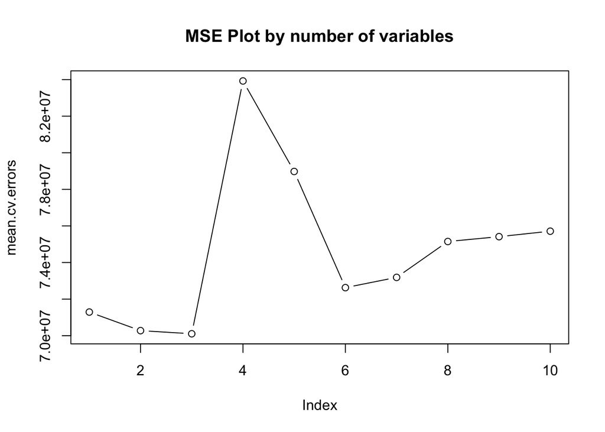

```r
# Set the plotting layout to a single panel
par(mfrow = c(1, 1))

# Plot the mean cross-validation errors
plot(mean.cv.errors, type = 'b', main = "MSE Plot by number of variables")
```

```r
reg.best=regsubsets(num_cases~.,data=numeric_data_311, nvmax=10)
print(coef(reg.best,4))
```

```
    (Intercept)         turnout turnout_two_lag      population           black
   -768.2909481     191.9592245    -230.2865316       0.3702609   11665.9673455
```

Part 3 Problem 1 – Regression

3-1 General Linear Model and Linear Model

```r
glm.fit_1 <- glm(num_cases ~ turnout + turnout_two_lag + population + black, data = numeric_data_311)
print(coef(glm.fit_1))
```

```
    (Intercept)         turnout turnout_two_lag      population           black
   -768.2909481     191.9592245    -230.2865316       0.3702609   11665.9673455
```

```r
set.seed(123)

n <- nrow(numeric_data_311)
indices <- sample(1:n, size = floor(0.8 * n))
train_set <- numeric_data_311[indices, ]
test_set <- numeric_data_311[-indices, ]

glm.fit_1 <- glm(num_cases ~ turnout + turnout_two_lag + population + black, data = train_set)

predictions_1 <- predict(glm.fit_1, test_set, type = "response")

mse_1 <- mean((test_set$num_cases - predictions_1)^2)
print(mse_1)
```

```
[1] 91004262
```

```r
lm.fit <- lm(num_cases ~ turnout + turnout_two_lag + population + black, data = train_set)

predictions_lm <- predict(lm.fit, test_set, type = "response")

mse_lm <- mean((test_set$num_cases - predictions_lm)^2)
print(mse_lm)
```

```
[1] 91004262
```

3-2 Ridge Regression

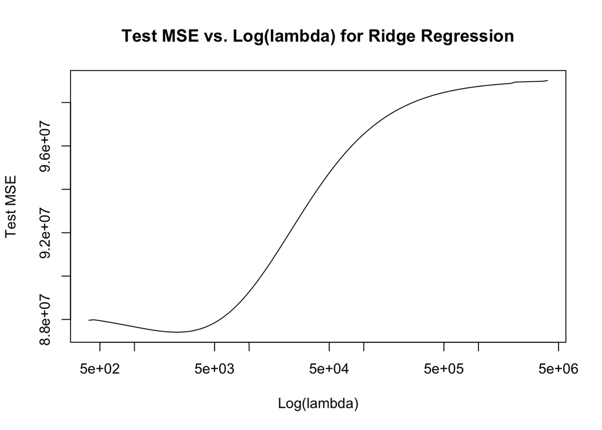

```r
require(glmnet)
x_train <- train_set %>%
  select(turnout, turnout_two_lag, population, black) %>%
  as.matrix()
y_train <- train_set$num_cases
x_test <- test_set %>%
  select(turnout, turnout_two_lag, population, black) %>%
  as.matrix()
y_test <- test_set$num_cases
set.seed(581)
cv_ridge <- cv.glmnet(x_train, y_train, alpha = 0, type.measure = "mse")
plot(cv_ridge$lambda, cv_ridge$cvm, type = 'l', xlab = "Log(lambda)", ylab = "Test MSE",
     log = "x")
title("Test MSE vs. Log(lambda) for Ridge Regression")
```

```r
best_lambda <- cv_ridge$lambda.min
ridge_pred <- predict(cv_ridge, s = best_lambda, newx = x_test)
ridge_test_error <- mean((y_test - ridge_pred)^2)
print(ridge_test_error)
```

```
[1] 89834339
```

3-3 LASSO Regression

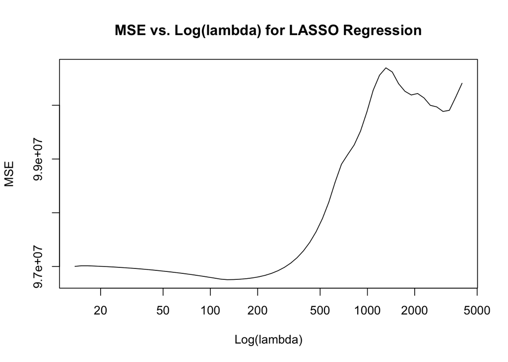

```r
library(glmnet)
cv_lasso <- cv.glmnet(x_train, y_train, alpha = 1, type.measure = "mse")
plot(cv_lasso$lambda, cv_lasso$cvm, type = 'l', xlab = "Log(lambda)", ylab = "MSE", log = "x")
title("MSE vs. Log(lambda) for LASSO Regression")
```

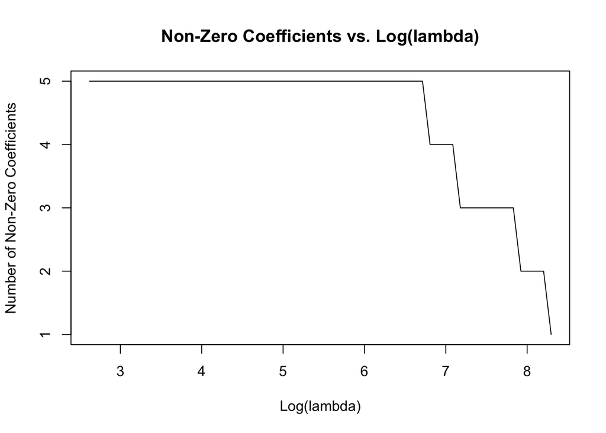

```r
plot(log(cv_lasso$lambda), colSums(coef(cv_lasso, s=cv_lasso$lambda) != 0), type='l', xlab = "Log(lambda)", ylab = "Number of Non-Zero Coefficients")
title("Non-Zero Coefficients vs. Log(lambda)")
```

```r
best_lambda <- cv_lasso$lambda.min
lasso_pred <- predict(cv_lasso, s = best_lambda, newx = x_test)
lasso_test_error <- mean((y_test - lasso_pred)^2)
print(lasso_test_error)
```

```
[1] 89712556
```

Part 4 Problem 2 – model selection

4-1 Best subset selection

```r
regfit_311=regsubsets(resolution_rate~.,numeric_data_311)
summary(regfit_311)
```

```
Subset selection object
Call: regsubsets.formula(resolution_rate ~ ., numeric_data_311)
10 Variables  (and intercept)
                Forced in Forced out
registered          FALSE      FALSE
turnout             FALSE      FALSE
turnout_one_lag     FALSE      FALSE
turnout_two_lag     FALSE      FALSE
income              FALSE      FALSE
population          FALSE      FALSE
white               FALSE      FALSE
black               FALSE      FALSE
asian               FALSE      FALSE
num_cases           FALSE      FALSE
1 subsets of each size up to 8
Selection Algorithm: exhaustive
         registered turnout turnout_one_lag turnout_two_lag income population
1  ( 1 ) " "        " "     " "             " "             "*"    " "
2  ( 1 ) " "        " "     " "             " "             "*"    " "
3  ( 1 ) " "        " "     " "             "*"             "*"    " "
4  ( 1 ) " "        " "     "*"             "*"             "*"    " "
5  ( 1 ) " "        " "     "*"             "*"             "*"    " "
6  ( 1 ) " "        " "     "*"             "*"             "*"    "*"
7  ( 1 ) " "        "*"     "*"             "*"             "*"    "*"
8  ( 1 ) "*"        "*"     "*"             "*"             "*"    "*"
         white black asian num_cases
1  ( 1 ) " "   " "   " "   " "
2  ( 1 ) "*"   " "   " "   " "
3  ( 1 ) "*"   " "   " "   " "
4  ( 1 ) "*"   " "   " "   " "
5  ( 1 ) "*"   "*"   " "   " "
6  ( 1 ) "*"   " "   "*"   " "
7  ( 1 ) "*"   " "   "*"   " "
8  ( 1 ) "*"   " "   "*"   " "
```

```r
reg.summary_8=summary(regfit_311)
```

```r
regfit_311_full=regsubsets(resolution_rate~.,numeric_data_311, nvmax=10)
summary(regfit_311_full)
```

```
Subset selection object
Call: regsubsets.formula(resolution_rate ~ ., numeric_data_311, nvmax = 10)
10 Variables  (and intercept)
                Forced in Forced out
registered          FALSE      FALSE
turnout             FALSE      FALSE
turnout_one_lag     FALSE      FALSE
turnout_two_lag     FALSE      FALSE
income              FALSE      FALSE
population          FALSE      FALSE
white               FALSE      FALSE
black               FALSE      FALSE
asian               FALSE      FALSE
num_cases           FALSE      FALSE
1 subsets of each size up to 10
Selection Algorithm: exhaustive
          registered turnout turnout_one_lag turnout_two_lag income population
1  ( 1 )  " "        " "     " "             " "             "*"    " "
2  ( 1 )  " "        " "     " "             " "             "*"    " "
3  ( 1 )  " "        " "     " "             "*"             "*"    " "
4  ( 1 )  " "        " "     "*"             "*"             "*"    " "
5  ( 1 )  " "        " "     "*"             "*"             "*"    " "
6  ( 1 )  " "        " "     "*"             "*"             "*"    "*"
7  ( 1 )  " "        "*"     "*"             "*"             "*"    "*"
8  ( 1 )  "*"        "*"     "*"             "*"             "*"    "*"
9  ( 1 )  "*"        "*"     "*"             "*"             "*"    "*"
10  ( 1 ) "*"        "*"     "*"             "*"             "*"    "*"
          white black asian num_cases
1  ( 1 )  " "   " "   " "   " "
2  ( 1 )  "*"   " "   " "   " "
3  ( 1 )  "*"   " "   " "   " "
4  ( 1 )  "*"   " "   " "   " "
5  ( 1 )  "*"   "*"   " "   " "
6  ( 1 )  "*"   " "   "*"   " "
7  ( 1 )  "*"   " "   "*"   " "
8  ( 1 )  "*"   " "   "*"   " "
9  ( 1 )  "*"   " "   "*"   "*"
10  ( 1 ) "*"   "*"   "*"   "*"
```

```r
reg.summary_10=summary(regfit_311_full)
```

```r
coef(regfit_311_full,10)
```

```
    (Intercept)      registered         turnout turnout_one_lag turnout_two_lag
   9.805859e-01   -3.392156e-07    3.866766e-04   -2.909219e-03   -3.182023e-03
         income      population           white           black           asian
  -2.073756e-06    1.060919e-06    4.371362e-01    3.608724e-02    1.898294e-01
      num_cases
   1.596764e-07
```

```r
print(reg.summary_10$rsq)# The last model with all variables performs the best
```

```
 [1] 0.2516969 0.2968510 0.3072423 0.3557954 0.3722976 0.3817843 0.3830220
 [8] 0.3838566 0.3839947 0.3841096
```

```r
print(reg.summary_10$adjr2)# The 6th variable without registered, turnout, black and num_cases performs the best
```

```
 [1] 0.2421033 0.2785874 0.2798966 0.3214379 0.3298853 0.3309720 0.3230380
 [8] 0.3144320 0.3047941 0.2948501
```

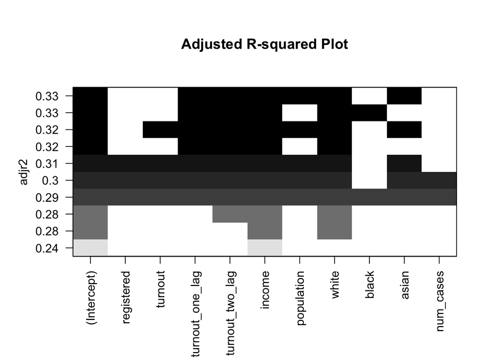

Fig-7: The adjusted R-squared of each model (step)

```r
plot(regfit_311_full,scale="adjr2", main = "Adjusted R-squared Plot")
```

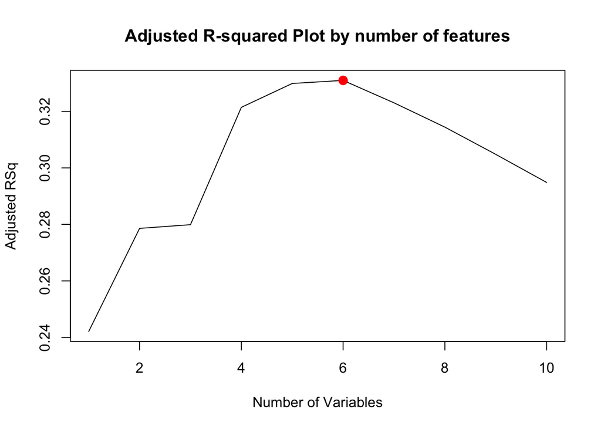

```r
plot(reg.summary_10$adjr2,xlab="Number of Variables",ylab="Adjusted RSq",type="l", main = "Adjusted R-squared Plot by number of features")
m=which.max(reg.summary_10$adjr2);
points(m,reg.summary_10$adjr2[m], col="red",cex=2,pch=20)
```

```r
plot(reg.summary_10$cp,xlab="Number of Variables",ylab="Cp",type='l', main = "Cp Plot by number of features")
m=which.min(reg.summary_10$cp)
print(c("optimal feature subset-size according to cp:",m))# The 4th model performs the best
```

```
[1] "optimal feature subset-size according to cp:"
[2] "4"
```

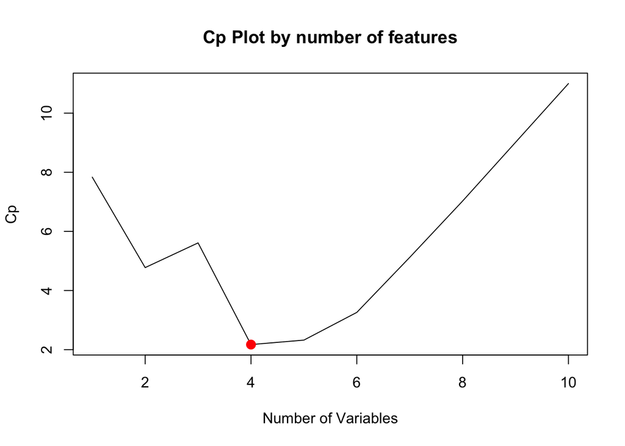

```r
points(m,reg.summary_10$cp[m],col="red",cex=2,pch=20)
```

```r
m=which.min(reg.summary_10$bic)
print(c("optimal feature subset-size according to BIC:",m))
```

```
[1] "optimal feature subset-size according to BIC:"
[2] "2"
```

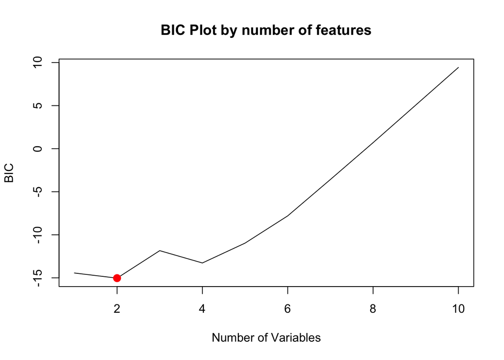

```r
plot(reg.summary_10$bic,xlab="Number of Variables",ylab="BIC",type='l', main = "BIC Plot by number of features")
points(m,reg.summary_10$bic[m],col="red",cex=2,pch=20) # Only income and white should be used
```

4-2 Forward and Backward stepwise selection

```r
regfit.fwd=regsubsets(resolution_rate~.,numeric_data_311, nvmax=10,method="forward")
summary(regfit.fwd)
```

```
Subset selection object
Call: regsubsets.formula(resolution_rate ~ ., numeric_data_311, nvmax = 10,
    method = "forward")
10 Variables  (and intercept)
                Forced in Forced out
registered          FALSE      FALSE
turnout             FALSE      FALSE
turnout_one_lag     FALSE      FALSE
turnout_two_lag     FALSE      FALSE
income              FALSE      FALSE
population          FALSE      FALSE
white               FALSE      FALSE
black               FALSE      FALSE
asian               FALSE      FALSE
num_cases           FALSE      FALSE
1 subsets of each size up to 10
Selection Algorithm: forward
          registered turnout turnout_one_lag turnout_two_lag income population
1  ( 1 )  " "        " "     " "             " "             "*"    " "
2  ( 1 )  " "        " "     " "             " "             "*"    " "
3  ( 1 )  " "        " "     " "             "*"             "*"    " "
4  ( 1 )  " "        " "     "*"             "*"             "*"    " "
5  ( 1 )  " "        " "     "*"             "*"             "*"    " "
6  ( 1 )  " "        "*"     "*"             "*"             "*"    " "
7  ( 1 )  " "        "*"     "*"             "*"             "*"    "*"
8  ( 1 )  " "        "*"     "*"             "*"             "*"    "*"
9  ( 1 )  "*"        "*"     "*"             "*"             "*"    "*"
10  ( 1 ) "*"        "*"     "*"             "*"             "*"    "*"
          white black asian num_cases
1  ( 1 )  " "   " "   " "   " "
2  ( 1 )  "*"   " "   " "   " "
3  ( 1 )  "*"   " "   " "   " "
4  ( 1 )  "*"   " "   " "   " "
5  ( 1 )  "*"   "*"   " "   " "
6  ( 1 )  "*"   "*"   " "   " "
7  ( 1 )  "*"   "*"   " "   " "
8  ( 1 )  "*"   "*"   "*"   " "
9  ( 1 )  "*"   "*"   "*"   " "
10  ( 1 ) "*"   "*"   "*"   "*"
```

```r
regfit.bwd=regsubsets(resolution_rate~.,numeric_data_311, nvmax=10,method="backward")
summary(regfit.bwd)
```

```
Subset selection object
Call: regsubsets.formula(resolution_rate ~ ., numeric_data_311, nvmax = 10,
    method = "backward")
10 Variables  (and intercept)
                Forced in Forced out
registered          FALSE      FALSE
turnout             FALSE      FALSE
turnout_one_lag     FALSE      FALSE
turnout_two_lag     FALSE      FALSE
income              FALSE      FALSE
population          FALSE      FALSE
white               FALSE      FALSE
black               FALSE      FALSE
asian               FALSE      FALSE
num_cases           FALSE      FALSE
1 subsets of each size up to 10
Selection Algorithm: backward
          registered turnout turnout_one_lag turnout_two_lag income population
1  ( 1 )  " "        " "     " "             " "             "*"    " "
2  ( 1 )  " "        " "     " "             " "             "*"    " "
3  ( 1 )  " "        " "     " "             "*"             "*"    " "
4  ( 1 )  " "        " "     "*"             "*"             "*"    " "
5  ( 1 )  " "        " "     "*"             "*"             "*"    " "
6  ( 1 )  " "        " "     "*"             "*"             "*"    "*"
7  ( 1 )  " "        "*"     "*"             "*"             "*"    "*"
8  ( 1 )  "*"        "*"     "*"             "*"             "*"    "*"
9  ( 1 )  "*"        "*"     "*"             "*"             "*"    "*"
10  ( 1 ) "*"        "*"     "*"             "*"             "*"    "*"
          white black asian num_cases
1  ( 1 )  " "   " "   " "   " "
2  ( 1 )  "*"   " "   " "   " "
3  ( 1 )  "*"   " "   " "   " "
4  ( 1 )  "*"   " "   " "   " "
5  ( 1 )  "*"   " "   "*"   " "
6  ( 1 )  "*"   " "   "*"   " "
7  ( 1 )  "*"   " "   "*"   " "
8  ( 1 )  "*"   " "   "*"   " "
9  ( 1 )  "*"   " "   "*"   "*"
10  ( 1 ) "*"   "*"   "*"   "*"
```